# MUM 2024-25 Problem klasyfikacji

## Zadanie klasyfikacji

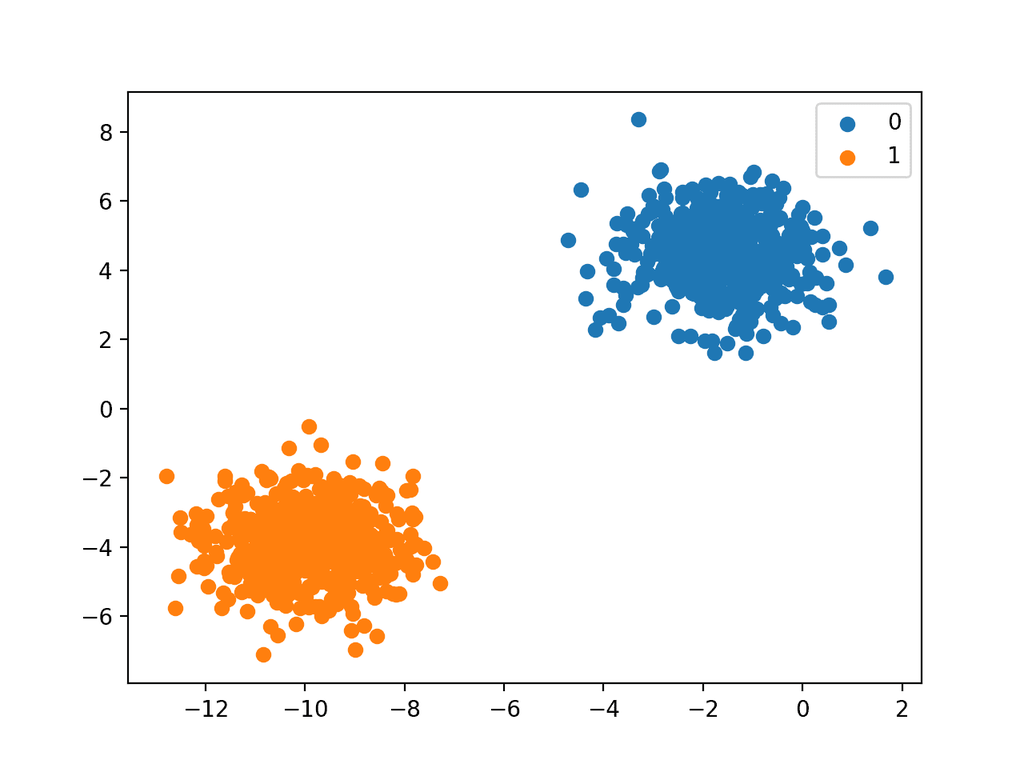

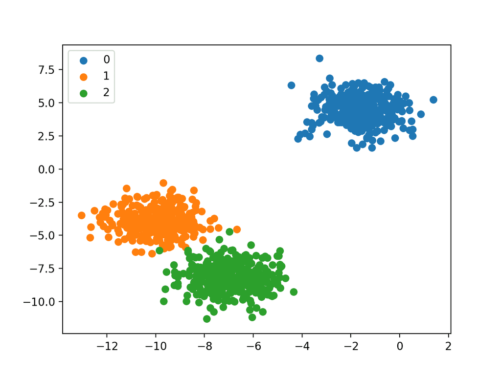

$y$ przyjmuje jedną z $K$ wartości $\{c_1, \ldots, c_K\}$ - **zbiór klas** * **klasyfikacja binarna** gdy $K=2$ * **klasyfikacja wieloklasowa** (*multi-class*) gdy $K>2$

## Reprezentacja klas w kodzie

1. jako liczba całkowita
   - $c_k$ reprezentowane jako liczba $k-1$
     - wprowadza fałszywy porządek - klasy w żaden sposób nie są semantycznie związane z liczbą
2. notacja **one-hot**
   - $c_k$ reprezentowane jako wektor $y=(0,\dots,0,1,0,\dots,0)$, jedynka na $k$-tej pozycji, zero na pozostałych
   - używana przez modele gradientowe
3. jako reprezentacja rozproszona (sparse)

## Maximum Likelihood w klasyfikacji

1. podwójne indeksy
- $(\mathbf{x}_n, y_n)$ to $n$-ty element zbioru treningowego
- $M_{\widehat\theta}(\mathbf{x}_n) = \widehat{\mathbf{p}}_n$
- $\widehat{\mathbf{p}}_n$ to $n$-ta predykcja (wektor)
- $c_k$ to $k$-ta klasa
- $\widehat{\mathbf{p}}_n = (\widehat{p}_{n,1}, \ldots, \widehat{p}_{n,K})$
- $\widehat{p}_{n,k}$ to $k$-ta współrzędna $n$-tej predykcji
- $\widehat{p}_{n,k}$ modeluje $p(y_n=c_k\mid\mathbf{x}_n)$
2. maksymalizujemy **warunkowe** likelihood
- likelihood $y_n$ pod warunkiem $\mathbf{x}_n$
- iloczyn po wszystkich parach $(\mathbf{x}_n, y_n)$ - **założenie I.I.D.**!
- potrzebujemy oznaczenia, które poda indeks $k$ klasy przykładu treningowego $y_n$
  - niech $c(y_n) = k$ wtedy i tylko wtedy, gdy $y_n = c_k$
- wzór na likelihood $$ \widehat{p}_{1,c(y_1)}\cdot\ldots\cdot\widehat{p}_{N,c(y_N)} = \prod_{n=1}^N \widehat{p}_{n,c(y_n)}$$
- negative mean log likelihood $$ -\dfrac{1}{N}\sum_{n=1}^N \ln[\widehat{p}_{n,c(y_n)}]$$
- maksimum likelihood $(y\mid\mathbf{x})$ to maksimum likelihood $y$ dla każdego $\mathbf{x}$ z osobna
  - $y$ może przyjąć skończenie wiele różnych wartości
  - wiemy, jak wygląda maximum likelihood $y$ - tak jak w modelu generatywnym

### Wnioski

1. niech pewna wartość $\mathbf{x}$ występuje **dokładnie raz** w zbiorze treiningowym
- załóżmy, że na $n$-tej pozycji $\mathbf{x}$ = $\mathbf{x}_n$
- model uczony maximum likelihood stwierdzi, że
  - $\widehat{p}(y=y_n\mid\mathbf{x}_n) = 1$
  - model **zapamięta** lub **memoryzuje** etykietę
  - prawdziwy rozkład $p(y\mid\mathbf{x}_n)$ może być zupełnie inny, ale mamy tylko jedną parę do estymacji
2. niech pewna wartość $\mathbf{x}$ występuje **kilka razy** w zbiorze treiningowym
- jak teraz wygląda $\widehat{p}(y\mid\mathbf{x}_n)$?
- czy to jest lepsza estymacja prawdziwego $p(y\mid\mathbf{x}_n)$?
- zazwyczaj $\mathbf{x}$ pochodzi z rozkładu ciągłego
  - żadna wartość $\mathbf{x}$ nie występuje wielokrotnie w zbiorze treningowym
3. załóżmy, że etykieta $y$ jest niezależna od $\mathbf{x}$
- model powinien się nauczyć zwracać zawsze rozkład $p(y)$
- model wiedzac o niezależności mógłby estymować $p(y)$ ze wszystkich $N$ przykładów $y_n$, nie patrząc w ogóle na $\mathbf{x}_n$
- czego nauczy się model?
4. załóżmy, że w **bliskim otoczeniu** pewnego $\mathbf{x}_n$ rozkład warunkowy $p(y\mid\mathbf{x})\simeq p(y\mid\mathbf{x}_n)$
- niech $\mathbf{x}_{n_1}, \mathbf{x}_{n_2}, \ldots, \mathbf{x}_{n_M}$ leżą w bliskim otoczeniu $\mathbf{x}_n$
- gdyby model wiedział, że rozkład $p(y\mid\mathbf{x})$ jest tu mniej więcej taki sam, to mógłby estymować go przy użyciu $M$ przykładów $y_{n_1}, \ldots, y_{n_M}$
  - model nauczy się pewnej estymacji

## Bezpośrednie uczenie funkcji dyskryminatywnej

1. być może potrzebujemy jedynie modelu, który **podejmuje decyzje**
   - czyli wskazuje jedną konkretną wartość $y$
2. mając nauczony łatwo zdefiniować funkcję dyskryminatywną
3. można od razu uczyć się funkcji dyskryminatywnej
   - potencjalnie łatwiej - nie trzeba modelować pełnego rozkładu $p(y\mid\mathbf{x})$
   - ale w takim razie nie ma likelihood, więc nie można uczyć metodą maximum likelihood
   - przykład: SVM

## Klasyfikacja wieloetykietowa

1. klasy nie są rozłączne
2. $y$ jest **podzbiorem** $\{c_1, \ldots, c_K\}$
3. można np. wytrenować $K$ klasyfikatorów binarnych
   - $k$-ty klasyfikator przewiduje, czy $\mathbf{x}$ ma etykietę $c_k$ (osobny sigmoid na każdym wyjściu)
   - podejście naiwne
     - w zasadzie równoważne uczeniu K klasyfikatorów
     - nie korzystamy z zależności pomiędzy różnymi etykietami (a to mogłoby pomóc)

## Nieskończenie wiele klas

1. czy można zrobić klasyfikator, jeśli $p(y\mid\mathbf{x})$ jest dyskretne na **nieskończonym** zbiorze?
2. w jaki sposób model może zwrócić nieskończenie wiele liczb?
3. jak poradzić sobie z faktem, że w **skończonym** zbiorze treningowym nie może wystąpić jednocześnie **nieskończenie wiele** klas?